Coding Essentials for Astronomers

# Image Fitting: Point Sources and Photometry

## Introduction

In Lecture 19, we analyzed time series data—measuring how stellar brightness changes over time to detect exoplanet transits. We learned to fit models to one-dimensional sequences of flux measurements, extracting physical parameters like planetary radii and orbital periods. Now we shift our focus from temporal to spatial data: analyzing two-dimensional images to measure stellar brightnesses and positions.

Photometry—measuring the brightness of celestial objects—is one of astronomy's most fundamental techniques. Every exoplanet transit, every supernova discovery, and every distance measurement to a distant galaxy ultimately relies on accurate photometry. Yet measuring a star's brightness from a digital image is more subtle than it might seem. Stars are essentially point sources—so distant that even the largest telescopes cannot resolve their disks—yet they appear as extended blobs in our images due to the finite resolution of our instruments.

This lecture teaches you the curve-fitting techniques needed to extract accurate photometry from astronomical images. You'll learn why stars appear extended despite being point sources, how the Point Spread Function (PSF) describes this light spreading, and how to fit PSF models and measure stellar brightnesses. We'll cover both aperture photometry (summing flux in circular regions) and PSF fitting (modeling the light distribution), understanding when each technique excels.

We'll explore why space telescopes like the James Webb Space Telescope (JWST) revolutionize photometry in crowded stellar fields through their superior angular resolution, and why PSF fitting becomes essential when stars overlap. By the end, you'll have hands-on experience with the same techniques professional astronomers use to measure stellar brightnesses and disentangle overlapping sources in dense star clusters.

```python
# Import required libraries
import numpy as np
import matplotlib.pyplot as plt
from scipy import optimize
from scipy import ndimage
from scipy import stats
from astropy import units as u
from astropy import constants as const

# Set random seed for reproducibility
np.random.seed(52)

# Configure matplotlib for better-looking plots
plt.rcParams['figure.dpi'] = 100
plt.rcParams['font.size'] = 10
```

## Why Stars Appear as Points: Angular Resolution

Before we discuss how to measure stellar brightness from images, we need to understand a fundamental question: Why do stars appear as point sources? The answer reveals the extraordinary scales of astronomy and the challenges of achieving high angular resolution.

Stars are enormous—our Sun has a radius of approximately 700,000 km, while red supergiants like Betelgeuse are hundreds of times larger. Yet these immense objects appear as points of light even through the largest telescopes. The reason is simple: they're incredibly far away. The angular size of a celestial object depends on both its physical size and its distance from Earth.

For an object of radius $R$ at distance $d$, the angular diameter $\theta$ (in radians) is given by the small-angle approximation:

$$\theta \approx \frac{2R}{d}$$

Astronomers typically measure angles in arcseconds, where $1'' = 1/3600$ degree. Let's calculate angular sizes using `astropy`:

```python
# Angular sizes for different stars
R_sun = const.R_sun  # Solar radius
```

The Sun as seen from Earth is enormous—it subtends about half a degree on the sky, large enough to resolve with the naked eye. But what about stars at typical astronomical distances?

```python
# Sun from Alpha Centauri (nearest star system, 4.37 light-years)
d_alpha_cen = 4.37 * u.lightyear
theta_alpha_cen = (2 * R_sun / d_alpha_cen).to(u.arcsec,
                                                 equivalencies=u.dimensionless_angles())

print(f"Sun from Alpha Centauri: {theta_alpha_cen.value:.6f} arcsec")
```

```
Sun from Alpha Centauri: 0.006942 arcsec
```

From Alpha Centauri, our Sun would appear tiny—only about 0.007 arcseconds across. This is far below the resolution of any telescope.

```python
# Betelgeuse: one of the largest nearby stars
R_betelgeuse = 700 * R_sun  # ~700× solar radius
d_betelgeuse = 548 * u.lightyear
theta_betelgeuse = (2 * R_betelgeuse / d_betelgeuse).to(u.arcsec,
                                                         equivalencies=u.dimensionless_angles())

print(f"Betelgeuse: {theta_betelgeuse.value:.4f} arcsec (diameter)")
```

```
Betelgeuse: 0.0387 arcsec (diameter)
```

This fundamental limitation—that stars appear as point sources—drives the techniques we'll learn in this lecture. Since we cannot resolve stellar disks, we must measure their brightness from the way their light spreads through our optical system. This spreading is described by the Point Spread Function.

## The Point Spread Function (PSF)

If stars are point sources, why do they appear as extended blobs in our images? The answer lies in the fundamental physics of light propagation and the imperfections of real optical systems. When light from a distant point source enters a telescope, it doesn't stay concentrated in a single pixel—it spreads into a characteristic pattern called the Point Spread Function (PSF).

The PSF arises from several physical effects. Diffraction occurs when light waves pass through the telescope's finite aperture, creating an unavoidable spreading pattern that sets the fundamental resolution limit. For ground-based telescopes, atmospheric turbulence dominates—turbulent air pockets with varying refractive indices distort incoming wavefronts, causing the "twinkling" we see with our eyes and creating larger, more irregular PSFs than diffraction alone. Optical aberrations from imperfect mirrors and lenses further broaden the PSF, as does charge diffusion in CCD detectors.

For ground-based telescopes, atmospheric seeing typically creates PSFs with full-width at half-maximum (FWHM) of 0.5 to 2 arcseconds. Space telescopes like JWST eliminate atmospheric effects entirely, achieving diffraction-limited performance with much sharper PSFs around 0.03 to 0.1 arcseconds depending on wavelength.

We often model the PSF as a 2D Gaussian function, which provides a simple yet effective analytical description:

$$\text{PSF}(x, y) = A \exp\left(-\frac{(x-x_0)^2 + (y-y_0)^2}{2\sigma^2}\right)$$

In this equation, $A$ represents the amplitude (peak height), $(x_0, y_0)$ is the center position of the PSF, and $\sigma$ is a parameter that determines how wide the function is.

Astronomers often describe the "width" of a star image by its full-width at half-maximum, or FWHM. The FWHM tells you how wide the profile is when it drops to half its maximum value—a useful, intuitive measure of how "blurry" or "spread out" the PSF appears. For a Gaussian profile, there is a simple mathematical relation between $\sigma$ and the FWHM:

$$ \mathrm{FWHM} = 2\sqrt{2\ln 2} \,\sigma \approx 2.355\,\sigma $$

That is, the FWHM is about 2.355 times the value of $\sigma$. When someone reports the "FWHM seeing" in arcseconds (for example), they mean this characteristic width of the PSF. This Gaussian model is particularly good for well-focused, seeing-limited observations from the ground or space.

Let's create and visualize a Gaussian PSF:

```python
# Create a 2D Gaussian PSF
size = 50  # pixels
x = np.arange(size)
y = np.arange(size)
x_grid, y_grid = np.meshgrid(x, y)

# PSF parameters
x0, y0 = size // 2, size // 2  # Center
amplitude = 1000.0  # Peak height
sigma = 3.0  # Width parameter
```

Now we generate the PSF using the Gaussian formula, calculating the squared distance from the center and applying the exponential function:

```python
# Calculate distances from center
r_squared = (x_grid - x0)**2 + (y_grid - y0)**2

# 2D Gaussian PSF
psf = amplitude * np.exp(-r_squared / (2 * sigma**2))

# Calculate FWHM
fwhm = 2.355 * sigma
```

We can visualize the PSF in multiple ways to understand its structure. Let's create a 2D image view, a cross-section through the center, and a radial profile:

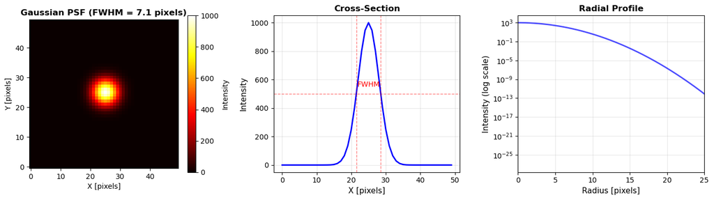

```python
fig, axes = plt.subplots(1, 3, figsize=(14, 4))

# 2D image
im1 = axes[0].imshow(psf, cmap='hot', origin='lower', interpolation='nearest')
axes[0].set_title(f'Gaussian PSF (FWHM = {fwhm:.1f} pixels)',
                  fontsize=12, fontweight='bold')
axes[0].set_xlabel('X [pixels]')
axes[0].set_ylabel('Y [pixels]')
plt.colorbar(im1, ax=axes[0], label='Intensity')

# Cross-section through center
center_slice = size // 2
axes[1].plot(x, psf[center_slice, :], 'b-', lw=2)
axes[1].axhline(amplitude / 2, color='red', ls='--', lw=1, alpha=0.5)
axes[1].axvline(x0 - fwhm/2, color='red', ls='--', lw=1, alpha=0.5)
axes[1].axvline(x0 + fwhm/2, color='red', ls='--', lw=1, alpha=0.5)
axes[1].set_xlabel('X [pixels]', fontsize=11)
axes[1].set_ylabel('Intensity', fontsize=11)
axes[1].set_title('Cross-Section', fontsize=12, fontweight='bold')
axes[1].grid(True, alpha=0.3)
axes[1].text(x0, amplitude*0.55, 'FWHM', ha='center', fontsize=10, color='red')

# Radial profile (log scale shows wings)
radius = np.sqrt((x_grid - x0)**2 + (y_grid - y0)**2).flatten()
intensity = psf.flatten()
sort_idx = np.argsort(radius)

axes[2].plot(radius[sort_idx], intensity[sort_idx], 'b-', lw=2, alpha=0.7)
axes[2].set_xlabel('Radius [pixels]', fontsize=11)
axes[2].set_ylabel('Intensity (log scale)', fontsize=11)
axes[2].set_title('Radial Profile', fontsize=12, fontweight='bold')
axes[2].set_yscale('log')
axes[2].grid(True, alpha=0.3, which='both')
axes[2].set_xlim(0, 25)

plt.tight_layout()
plt.show()
```

The visualization shows the key features of a PSF. The central peak contains most of the star's light, with intensity dropping off rapidly with distance. The FWHM marks the radius where intensity falls to half the peak value—this is the standard measure of PSF size. In the log-scale radial plot, we see that the Gaussian PSF has extended wings that continue far from the center, though with exponentially decreasing intensity.

### Ground-Based vs Space-Based: The JWST Advantage

The choice between ground-based and space-based telescopes has profound implications for photometry, especially in crowded stellar fields. Ground-based telescopes typically achieve PSF FWHM of 0.5 to 2 arcseconds, limited by atmospheric seeing. The PSF shape has extended wings due to turbulence, and the PSF varies on timescales of minutes as seeing conditions change. In contrast, JWST achieves PSF FWHM of 0.03 to 0.1 arcseconds depending on wavelength. The PSF is diffraction-limited, stable, and well-characterized with no atmospheric interference.

Let's visualize this dramatic difference with a crowded field example:

```python
# Simulate two close stars with different PSFs
# Separation: 0.15 arcsec, pixel scale: 0.03 arcsec/pixel (JWST-like)
pixel_scale = 0.03  # arcsec/pixel
separation_arcsec = 0.15  # arcsec between stars
separation_pixels = separation_arcsec / pixel_scale  # = 5 pixels

size_crowd = 40
x_crowd = np.arange(size_crowd)
y_crowd = np.arange(size_crowd)
x_grid_crowd, y_grid_crowd = np.meshgrid(x_crowd, y_crowd)

# Star positions
x1 = size_crowd // 2 - separation_pixels / 2
y1 = size_crowd // 2
x2 = size_crowd // 2 + separation_pixels / 2
y2 = size_crowd // 2

# Brightnesses
amp1, amp2 = 1000, 800
```

Now we generate images with JWST and ground-based PSFs to demonstrate the dramatic difference in resolution:

```python
# JWST case: FWHM = 0.06 arcsec = 2 pixels
sigma_jwst = 0.06 / pixel_scale / 2.355

r1_jwst = np.sqrt((x_grid_crowd - x1)**2 + (y_grid_crowd - y1)**2)
r2_jwst = np.sqrt((x_grid_crowd - x2)**2 + (y_grid_crowd - y2)**2)
jwst_image = (amp1 * np.exp(-r1_jwst**2 / (2 * sigma_jwst**2)) +
              amp2 * np.exp(-r2_jwst**2 / (2 * sigma_jwst**2)))

# Ground-based: FWHM = 1.2 arcsec = 40 pixels
sigma_ground = 1.2 / pixel_scale / 2.355

r1_ground = np.sqrt((x_grid_crowd - x1)**2 + (y_grid_crowd - y1)**2)
r2_ground = np.sqrt((x_grid_crowd - x2)**2 + (y_grid_crowd - y2)**2)
ground_image = (amp1 * np.exp(-r1_ground**2 / (2 * sigma_ground**2)) +
                amp2 * np.exp(-r2_ground**2 / (2 * sigma_ground**2)))
```

Let's compare the two images side by side to see how the different PSF sizes affect our ability to resolve the stars:

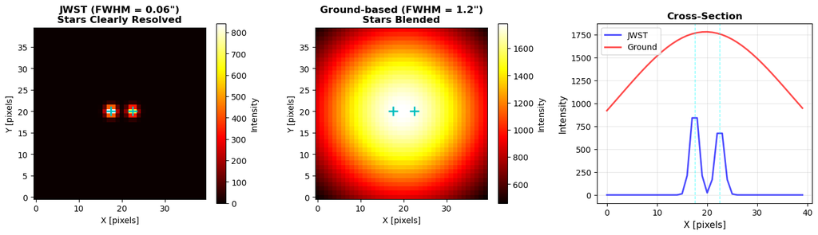

```python
fig, axes = plt.subplots(1, 3, figsize=(14, 4))

# JWST image
im1 = axes[0].imshow(jwst_image, cmap='hot', origin='lower', interpolation='nearest')
axes[0].plot([x1, x2], [y1, y2], 'c+', markersize=12, markeredgewidth=2)
axes[0].set_title('JWST (FWHM = 0.06")\nStars Clearly Resolved',
                  fontsize=12, fontweight='bold')
axes[0].set_xlabel('X [pixels]')
axes[0].set_ylabel('Y [pixels]')
plt.colorbar(im1, ax=axes[0], label='Intensity')

# Ground-based image
im2 = axes[1].imshow(ground_image, cmap='hot', origin='lower', interpolation='nearest')
axes[1].plot([x1, x2], [y1, y2], 'c+', markersize=12, markeredgewidth=2)
axes[1].set_title('Ground-based (FWHM = 1.2")\nStars Blended',
                  fontsize=12, fontweight='bold')
axes[1].set_xlabel('X [pixels]')
axes[1].set_ylabel('Y [pixels]')
plt.colorbar(im2, ax=axes[1], label='Intensity')

# Cross-section comparison
y_slice = size_crowd // 2
axes[2].plot(x_crowd, jwst_image[y_slice, :], 'b-', lw=2, label='JWST', alpha=0.7)
axes[2].plot(x_crowd, ground_image[y_slice, :], 'r-', lw=2, label='Ground', alpha=0.7)
axes[2].axvline(x1, color='cyan', ls='--', lw=1, alpha=0.5)
axes[2].axvline(x2, color='cyan', ls='--', lw=1, alpha=0.5)
axes[2].set_xlabel('X [pixels]', fontsize=11)
axes[2].set_ylabel('Intensity', fontsize=11)
axes[2].set_title('Cross-Section', fontsize=12, fontweight='bold')
axes[2].legend()
axes[2].grid(True, alpha=0.3)

plt.tight_layout()
plt.show()
```

This is why JWST revolutionizes studies of crowded stellar fields like globular clusters, the Galactic center, and distant galaxies. The superior angular resolution allows precise photometry of individual stars where ground-based telescopes see only unresolved blurs.

### Adaptive Optics: Combining Ground-Based and Space-Based Advantages

The comparison between ground-based and space telescopes reveals a fundamental trade-off. Ground-based telescopes can be much larger and cheaper—we can build 10-meter class telescopes on Earth for a fraction of the cost of launching even a 6.5-meter telescope (JWST) into space. Larger apertures collect more light, enabling observations of fainter objects and providing better diffraction-limited resolution. However, atmospheric seeing degrades this potential, limiting resolution to about 1 arcsecond regardless of telescope size.

Space telescopes achieve diffraction-limited performance with sharp, stable PSFs but are limited in size by launch constraints and cost. JWST's 6.5-meter primary mirror was an extraordinary engineering achievement, segmented to fold for launch. Building significantly larger space telescopes remains prohibitively expensive.

Adaptive optics (AO) attempts to overcome atmospheric limitations while keeping the advantages of large ground-based telescopes. The concept is elegant: measure the atmospheric distortions in real-time and correct them using a deformable mirror that adjusts its shape hundreds of times per second.

Here's how it works. A wavefront sensor measures how atmospheric turbulence has distorted the incoming light from a bright reference star (natural guide star) or an artificial laser guide star. A computer calculates the required mirror corrections to compensate for these distortions. A deformable mirror with hundreds of actuators adjusts its surface to cancel out the atmospheric aberrations. When working properly, AO can achieve near-diffraction-limited performance with PSF FWHM around 0.05 arcseconds in the near-infrared—approaching space-based quality with ground-based apertures.

However, adaptive optics has important limitations. It works best in the near-infrared where atmospheric turbulence has less effect than at optical wavelengths. The correction is typically good only over small fields of view (tens of arcseconds), though multi-conjugate AO systems are improving this. A bright reference star near the target is needed, or laser guide stars must be used. The systems are expensive and complex to operate, requiring sophisticated real-time control systems.

Despite these challenges, AO has transformed ground-based astronomy. Facilities like the Keck Observatory with AO and the upcoming Extremely Large Telescope (39-meter aperture) with advanced AO systems will achieve unprecedented combinations of light-gathering power and angular resolution. For many science cases—especially those requiring small fields of view in the near-infrared—AO-equipped ground-based telescopes can rival or exceed space telescopes while being more accessible and less expensive.

## Creating a Synthetic Star Field

We've now explored how stars appear as PSFs in our images, why space-based telescopes achieve superior resolution, and how different observing strategies affect the data we collect. With this theoretical foundation in place, it's time to get practical. To learn photometry techniques effectively, we'll create realistic synthetic images with known properties. This allows us to test our methods and understand their accuracy. A typical astronomical image contains three components: a background level, stellar sources (each represented by a PSF), and noise.

### Image Components

Every astronomical image has a roughly uniform background from sky emission, scattered light, and detector bias. This is typically 100 to 1000 counts per pixel. Each star contributes a PSF centered at its position, with amplitude proportional to its brightness. Noise comes from two main sources: Poisson noise from the random arrival of photons (uncertainty $\sqrt{N}$ for $N$ photons), and read noise from electronics in the detector (typically 5-15 electrons RMS per pixel).

Let's build a synthetic image step by step:

```python
# Image parameters
image_size = 200  # pixels
n_stars = 5  # number of stars
background_level = 100.0  # counts per pixel
read_noise = 10.0  # electrons per pixel
psf_sigma = 2.5  # pixels (FWHM ~ 6 pixels, space-quality)
```

We'll generate random star positions, keeping them away from the image edges to avoid edge effects in our photometry:

```python
# Star positions (margin to keep away from edges)
margin = 15
np.random.seed(522)
star_x = np.random.uniform(margin, image_size - margin, n_stars)
star_y = np.random.uniform(margin, image_size - margin, n_stars)
```

We generate star brightnesses following a log-normal distribution, which is realistic for star fields since stellar luminosities span many orders of magnitude:

```python
# Star brightnesses (log-normal distribution)
mean_log_brightness = np.log(800)
std_log_brightness = 0.6
star_amplitudes = np.exp(np.random.normal(mean_log_brightness, std_log_brightness, n_stars))

print(f"Star amplitudes: {star_amplitudes.min():.0f} to {star_amplitudes.max():.0f} counts")
print(f"Median amplitude: {np.median(star_amplitudes):.0f} counts")
```

```
Star amplitudes: 289 to 2103 counts
Median amplitude: 607 counts
```

We create the base image by initializing it with a uniform background level across all pixels:

```python
# Create coordinate grids
x_im = np.arange(image_size)
y_im = np.arange(image_size)
x_grid_im, y_grid_im = np.meshgrid(x_im, y_im)

# Initialize with background
image = np.full((image_size, image_size), background_level)
```

Now we add each star to the image as a Gaussian PSF centered at its position:

```python
# Add each star
for i in range(n_stars):
    r_squared = (x_grid_im - star_x[i])**2 + (y_grid_im - star_y[i])**2
    star_psf = star_amplitudes[i] * np.exp(-r_squared / (2 * psf_sigma**2))
    image += star_psf
```

Now add realistic noise. Poisson noise represents photon counting statistics, and read noise represents detector electronics:

```python
# Add Poisson noise (photon statistics)
poisson_noise = np.random.poisson(image).astype(float) - image

# Add read noise (Gaussian, from detector electronics)
read_noise_array = np.random.normal(0, read_noise, image.shape)

# Final noisy image
image_noisy = image + poisson_noise + read_noise_array
image_noisy = np.maximum(image_noisy, 0)  # No negative values
```

Let's visualize the synthetic image to see how it compares to real astronomical data:

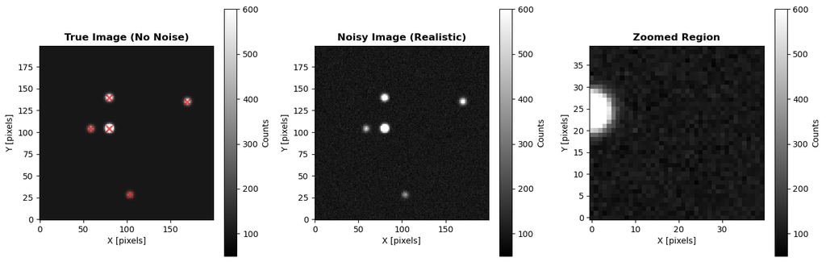

```python
fig, axes = plt.subplots(1, 3, figsize=(14, 4.5))

# True noiseless image
im1 = axes[0].imshow(image, cmap='gray', origin='lower', interpolation='nearest',
                     vmin=background_level - 50, vmax=background_level + 500)
axes[0].scatter(star_x, star_y, c='red', s=50, marker='x', alpha=0.7, linewidths=2)
axes[0].set_title('True Image (No Noise)', fontsize=12, fontweight='bold')
axes[0].set_xlabel('X [pixels]')
axes[0].set_ylabel('Y [pixels]')
plt.colorbar(im1, ax=axes[0], label='Counts')

# Noisy image (realistic)
im2 = axes[1].imshow(image_noisy, cmap='gray', origin='lower', interpolation='nearest',
                     vmin=background_level - 50, vmax=background_level + 500)
axes[1].set_title('Noisy Image (Realistic)', fontsize=12, fontweight='bold')
axes[1].set_xlabel('X [pixels]')
axes[1].set_ylabel('Y [pixels]')
plt.colorbar(im2, ax=axes[1], label='Counts')

# Zoom into a region
zoom_size = 40
zoom_x, zoom_y = 80, 80
im3 = axes[2].imshow(image_noisy[zoom_y:zoom_y+zoom_size, zoom_x:zoom_x+zoom_size],
                     cmap='gray', origin='lower', interpolation='nearest',
                     vmin=background_level - 50, vmax=background_level + 500)
axes[2].set_title('Zoomed Region', fontsize=12, fontweight='bold')
axes[2].set_xlabel('X [pixels]')
axes[2].set_ylabel('Y [pixels]')
plt.colorbar(im3, ax=axes[2], label='Counts')

plt.tight_layout()
plt.show()
```

The synthetic image captures the essential features of real astronomical data. Stars appear as PSF-shaped blobs against a noisy background. The noise is most apparent in background regions—these random fluctuations create the grainy texture visible in the image. This synthetic image will serve as our testbed for photometry techniques.

The noise in our synthetic image comes from two main sources, and it's important to understand them for accurate photometry. Both affect real astronomical images, but their importance depends on how bright your sources are and the details of your detector.

### Poisson (Photon) Noise

Poisson (or photon) noise arises because the arrival of photons at each pixel is a random process. Even if the expected number of photons is the same, some pixels will randomly receive more or fewer photons than others. This variability follows Poisson statistics: the standard deviation in the photon count is the square root of the average number expected.

For example, if a pixel expects 100 photons, the measured value will typically be around 100, with an uncertainty of about 10 (since $\sqrt{100} = 10$). With 10,000 photons, the uncertainty becomes 100, so measurements would be $10,000 \pm 100$. As the photon count increases, the *absolute* uncertainty becomes larger (from 10 to 100), but the *relative* uncertainty decreases (from 10% to 1%). This is why brighter sources have higher signal-to-noise ratios and why longer exposures help when observing faint objects.

Both star pixels and background pixels are affected by Poisson noise. For instance, a pixel with 100 background counts has a Poisson uncertainty of 10, while a star pixel with 1000 counts has about 32 counts of Poisson noise. When we subtract the background to isolate the star, the resulting uncertainty is the quadrature sum (i.e., $\sqrt{10^2 + 32^2} \approx 34$ in this example), meaning our measurement of the star's brightness always incorporates both background and source noise.

The crucial takeaway: Poisson noise is a fundamental property of photon detection. It’s a natural, unavoidable uncertainty that is always present, no matter how perfect the detector.

### Read Noise

While Poisson noise reflects the quantum nature of light itself, there's a second source of uncertainty that arises from our imperfect detectors. Read noise comes from the electronics of the detector itself. When the CCD reads the accumulated charge in each pixel, the amplifiers introduce a small amount of additional, random noise that is not related to the photon arrival rate. This type of noise is typically about 3-5 electrons per pixel for modern detectors, or 10-15 electrons for older cameras. Importantly, read noise is independent of the actual signal: every pixel experiences the same read noise, whether it is bright or faint.

The key difference between read noise and Poisson noise is that **read noise is the same for every pixel, regardless of how many photons were collected**. Whether a pixel receives 10 photons or 10,000 photons, it experiences the same ~3-10 electrons of read noise. In contrast, while Poisson noise's absolute value increases with signal (σ = √N), the signal-to-noise ratio actually improves: SNR = N/√N = √N. So more photons give you better measurements, not worse ones.

For faint pixels (few photons), read noise can be the dominant source of uncertainty. For bright pixels (many photons), Poisson noise dominates and read noise becomes negligible. This is why longer exposures help with faint objects—they increase the signal (and Poisson noise) while read noise stays constant, improving the overall signal-to-noise ratio.

### From Photons to Counts: CCD Calibration

Now that we understand how noise affects our measurements, it's worth stepping back to clarify what we're actually measuring. Throughout this lecture, we've been measuring fluxes in "counts" per pixel. But what are these counts, and how do they relate to the light from a star? Understanding the calibration chain from photons to counts is essential for accurate photometry.

**The Measurement Chain:**

The process of converting incoming light into digital counts involves several steps:

1. **Photons → Electrons**: When photons hit the CCD detector, they create electrons through the photoelectric effect. The efficiency of this conversion is called the quantum efficiency (QE), typically 0.8-0.9 for modern CCDs in the optical. So if 100 photons hit a pixel, we might get ~85 electrons.
2. **Electrons accumulate**: During the exposure time, electrons accumulate in each pixel. The number of electrons is proportional to the number of photons received and the exposure time.
3. **Electrons → ADUs (counts)**: When the CCD is read out, the accumulated charge (electrons) is converted to a digital number called an ADU (Analog-to-Digital Unit) or "count". This conversion is controlled by the detector's gain:

$$\text{ADU} = \frac{\text{electrons}}{\text{gain}}$$

Typical gain values are 1-3 electrons per ADU for modern CCDs. For example, with a gain of 2 e⁻/ADU, 1000 electrons become 500 ADUs.

**Calibrating Back to Photons:**

To recover the original photon count from measured ADUs, we reverse the chain:

$$\text{Photons} = \frac{\text{ADUs} \times \text{gain}}{\text{quantum efficiency}}$$

For example, if we measure 500 ADUs with gain = 2 e⁻/ADU and QE = 0.85:

- Electrons = 500 × 2 = 1000 electrons
- Photons = 1000 / 0.85 ≈ 1176 photons

Understanding this calibration is crucial. Noise calculations—particularly those involving Poisson noise—should be performed using photon counts rather than ADUs. Proper calibration becomes essential if you want to compare observations from different instruments. In practice, professional pipelines handle this calibration automatically using calibration frames. For our synthetic images, we're working directly in counts and can compare relative brightnesses without worrying about absolute calibration. But for real science, converting instrumental measurements to calibrated fluxes is essential.

## Background Estimation and Subtraction

With our synthetic image in hand and an understanding of its noise properties, we're ready to begin extracting photometric measurements. But there's an essential preprocessing step we must complete first: background subtraction. Just as we carefully constructed our synthetic image by adding background, stars, and noise, we must now reverse-engineer the image to separate the stellar signal from the background before we can measure stellar brightnesses accurately.

Before measuring stellar brightnesses, we must first estimate and subtract the background. The background represents all flux sources except the stars we're trying to measure: sky emission, scattered light in the telescope, and detector bias. Accurate background subtraction is crucial because errors propagate directly into photometric measurements.

The simplest approach uses robust statistics. Since most pixels contain only background (stars are sparse), the median or sigma-clipped mean provides a good estimate. The median is robust to outliers, naturally ignoring the bright star pixels.

Calculate the simple median:

```python
# Simple median (robust to stars which are outliers)
background_median = np.median(image_noisy)
```

For better accuracy, we use sigma-clipping—an iterative algorithm that rejects outliers before computing statistics. The method works as follows: First, compute the mean and standard deviation of all pixels. Then identify pixels that deviate by more than $N\sigma$ from the mean (typically $N=3$). Remove these outlier pixels and repeat with the remaining data. After a few iterations, we converge to a clean sample containing only background pixels, with stars removed.

This sigma-clipped mean is more accurate than the simple median because it uses more information (all background pixels, not just the middle value) while still rejecting stars. Let's implement it:

```python
# Sigma-clipped statistics
clipped_data = image_noisy.flatten().copy()

for iteration in range(5):
    mean = np.mean(clipped_data)
    std = np.std(clipped_data)
    # Keep only pixels within 3σ of mean
    mask = np.abs(clipped_data - mean) < 3 * std
    clipped_data = clipped_data[mask]

bg_mean = np.mean(clipped_data)
bg_std = np.std(clipped_data)

print(f"Background level: {bg_mean:.2f} counts/pixel")
print(f"Background noise (std): {bg_std:.2f} counts/pixel")
```

```
Background level: 100.14 counts/pixel
Background noise (std): 14.03 counts/pixel
```

The sigma-clipped mean gives us both the background level and an estimate of the noise, which we'll use later for source detection. The standard deviation represents the typical pixel-to-pixel variation in the background, combining Poisson noise from the background itself and read noise from the detector.

Now we subtract the estimated background level from the entire image:

```python
# Background-subtracted image
image_bgsub = image_noisy - bg_mean
```

Let's visualize the effect of background subtraction by comparing the original and background-subtracted images:

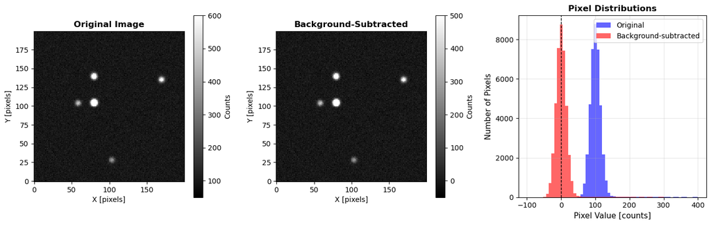

```python
fig, axes = plt.subplots(1, 3, figsize=(14, 4.5))

# Original
im1 = axes[0].imshow(image_noisy, cmap='gray', origin='lower', interpolation='nearest',
                     vmin=50, vmax=600)
axes[0].set_title('Original Image', fontsize=12, fontweight='bold')
axes[0].set_xlabel('X [pixels]')
axes[0].set_ylabel('Y [pixels]')
plt.colorbar(im1, ax=axes[0], label='Counts')

# Background-subtracted
im2 = axes[1].imshow(image_bgsub, cmap='gray', origin='lower', interpolation='nearest',
                     vmin=-50, vmax=500)
axes[1].set_title('Background-Subtracted', fontsize=12, fontweight='bold')
axes[1].set_xlabel('X [pixels]')
axes[1].set_ylabel('Y [pixels]')
plt.colorbar(im2, ax=axes[1], label='Counts')

# Histogram comparison
axes[2].hist(image_noisy.flatten(), bins=50, alpha=0.6, label='Original',
             color='blue', range=(0, 400))
axes[2].hist(image_bgsub.flatten(), bins=50, alpha=0.6, label='Background-subtracted',
             color='red', range=(-100, 300))
axes[2].axvline(0, color='black', ls='--', lw=1)
axes[2].set_xlabel('Pixel Value [counts]', fontsize=11)
axes[2].set_ylabel('Number of Pixels', fontsize=11)
axes[2].set_title('Pixel Distributions', fontsize=12, fontweight='bold')
axes[2].legend()
axes[2].grid(True, alpha=0.3)

plt.tight_layout()
plt.show()
```

After background subtraction, the image now has mean near zero—background regions fluctuate around zero due to noise, while stars remain as positive peaks. This is the ideal format for source detection and photometry.

## Source Detection

Now that we have subtracted the background, the image primarily contains noise (which fluctuates around zero) and distinct peaks corresponding to stars. Our goal is to identify these stars by locating pixels that are both significantly brighter than the noise and are local maxima.

For this, we use a detection threshold to help distinguish real sources from random noise fluctuations. Since the background noise is approximately Gaussian, a threshold of 5σ (five standard deviations above the mean) is very robust: only about 1 in a million noise-only pixels would randomly exceed this value. This makes it highly probable that any pixel above this threshold corresponds to a genuine astronomical source rather than noise.

We also require sources to be local maxima, meaning their value is the highest among their immediate neighbors. To efficiently identify such peaks, we use `scipy.ndimage.maximum_filter`, which finds pixels brighter than all their surrounding pixels within a window of a chosen size (typically the FWHM of the PSF).

Let's now define our detection threshold at 5σ above the (now-zero) background and proceed toward star finding:

```python
# Detection threshold
detection_threshold = 5 * bg_std

print(f"Detection threshold: {detection_threshold:.2f} counts (5σ)")
```

```
Detection threshold: 70.14 counts (5σ)
```

For Gaussian noise, only about 1 in a million pixels exceeds 5σ by chance, so this threshold reliably rejects noise fluctuations while keeping real sources.

### Finding Local Maxima with scipy.ndimage.maximum_filter

To identify stars, we need to find pixels that are local maxima—brighter than all their neighbors. The `scipy.ndimage.maximum_filter` function is perfect for this. It works by sliding a window (filter) across the image and, for each pixel, replacing its value with the maximum value within the window. If a pixel's value equals the maximum in its neighborhood after this operation, it must be a local peak.

The key parameter is `size`, which defines the filter window dimensions. We set this to approximately the PSF FWHM to avoid detecting multiple peaks on a single star (caused by noise) while still resolving separate stars. Here's how it works:

```python
# Find local maxima
filter_size = int(np.ceil(2.355 * psf_sigma))  # ~FWHM
local_max = ndimage.maximum_filter(image_bgsub, size=filter_size)
```

The `maximum_filter` returns an array where each pixel contains the maximum value within a `filter_size × filter_size` window centered on that pixel. For a star, the central pixel (peak) will equal this local maximum, but surrounding pixels will not.

Now we identify which pixels are actual peaks by checking if they equal the local maximum and exceed our detection threshold:

```python
# A pixel is a peak if it equals the local maximum AND exceeds threshold
is_peak = (image_bgsub == local_max) & (image_bgsub > detection_threshold)

# Get coordinates
detected_y, detected_x = np.where(is_peak)
n_detected = len(detected_x)

print(f"Detected {n_detected} sources (true number: {n_stars})")
```

```
Detected 5 sources (true number: 5)
```

This approach finds all pixels that are simultaneously the brightest in their local neighborhood and above our significance threshold. Let's visualize the detections:

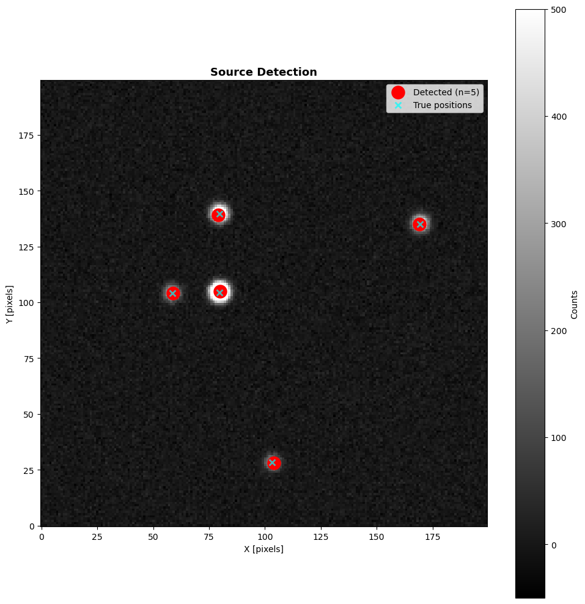

```python
fig, ax = plt.subplots(1, 1, figsize=(10, 10))

im = ax.imshow(image_bgsub, cmap='gray', origin='lower', interpolation='nearest',
               vmin=-50, vmax=500)
ax.scatter(detected_x, detected_y, c='red', s=200, marker='o',
          facecolors='none', edgecolors='red', linewidths=2, label=f'Detected (n={n_detected})')
ax.scatter(star_x, star_y, c='cyan', s=50, marker='x',
          linewidths=2, label='True positions', alpha=0.7)
ax.set_title('Source Detection', fontsize=13, fontweight='bold')
ax.set_xlabel('X [pixels]')
ax.set_ylabel('Y [pixels]')
ax.legend()
plt.colorbar(im, ax=ax, label='Counts')

plt.tight_layout()
plt.show()
```

The detected positions are close to the true positions, confirming our detection method works well. These approximate positions will serve as starting points for more accurate measurements.

## Aperture Photometry

Having identified where the stars are located in our image, we're now ready to measure how bright they are. The most straightforward approach is aperture photometry, which you can think of as drawing a circle around each star and counting up all the flux within that circle. While conceptually simple, implementing aperture photometry correctly requires careful attention to a few key details—particularly how we handle the local background around each star.

In aperture photometry, we sum all flux within a circular aperture centered on each source, subtracting a local background estimated from an annular region around the star.

For a star at position $(x_0, y_0)$, we define a source aperture of radius $r_{\text{ap}}$ and a sky annulus from radius $r_{\text{in}}$ to $r_{\text{out}}$. The star's flux is the sum in the aperture minus the background contribution:

$$F_{\text{star}} = \sum_{\text{aperture}} (\text{pixel value}) - N_{\text{ap}} \times \langle \text{sky} \rangle$$

where $N_{\text{ap}}$ is the number of aperture pixels and $\langle \text{sky} \rangle$ is the median sky level in the annulus.

**Why do we need a local sky annulus even after global background subtraction?** This is a crucial point that often confuses students. While we've already subtracted a global background estimate from the entire image, the background level can vary spatially across the field. Sky emission, scattered light, and detector effects can create local variations—the background near one star might be slightly different from the background near another star, or from the global average. Additionally, even if the global background is perfectly uniform, using a local annulus provides a more accurate measurement because it samples the background in the immediate vicinity of each star, accounting for any residual spatial variations. The annulus also helps account for any systematic errors in the global background subtraction. By measuring the local background around each star individually, we ensure that our photometry is as accurate as possible.

We set the aperture parameters based on the PSF FWHM to optimize flux collection while minimizing background noise:

```python
# Aperture sizes
fwhm = 2.355 * psf_sigma
aperture_radius = 2.5 * fwhm
sky_inner_radius = 3.0 * fwhm
sky_outer_radius = 4.0 * fwhm

print(f"FWHM: {fwhm:.2f} pixels")
print(f"Aperture radius: {aperture_radius:.2f} pixels")
print(f"Sky annulus: {sky_inner_radius:.2f} to {sky_outer_radius:.2f} pixels")
```

```
FWHM: 5.89 pixels
Aperture radius: 14.72 pixels
Sky annulus: 17.66 to 23.55 pixels
```

Before measuring all sources, let's understand the method by measuring one star in detail. We'll create masks for the aperture and sky annulus regions, then compute the flux:

```python
# Measure photometry for the brightest detected star
brightest_idx = 0  # We'll update this after measuring all stars

# For now, measure the first star
x_center = detected_x[0]
y_center = detected_y[0]

# Create distance array
y_grid, x_grid = np.ogrid[0:image_size, 0:image_size]
r = np.sqrt((x_grid - x_center)**2 + (y_grid - y_center)**2)

# Define masks
aperture_mask = (r <= aperture_radius)
sky_mask = (r >= sky_inner_radius) & (r <= sky_outer_radius)

# Sky background
sky_pixels = image_bgsub[sky_mask]
sky_median = np.median(sky_pixels)

# Source flux
aperture_pixels = image_bgsub[aperture_mask]
n_aperture_pixels = len(aperture_pixels)
flux = np.sum(aperture_pixels) - n_aperture_pixels * sky_median
```

The sky subtraction is crucial: without it, we'd be counting background in every aperture pixel. For a 100-pixel aperture with 100 counts/pixel background, that's 10,000 spurious counts!

Now we apply this aperture photometry method to all detected sources in the image:

```python
# Measure all detected sources
aperture_fluxes = []

for i in range(n_detected):
    x_c, y_c = detected_x[i], detected_y[i]
    r = np.sqrt((x_grid - x_c)**2 + (y_grid - y_c)**2)

    # Masks
    ap_mask = (r <= aperture_radius)
    sky_mask = (r >= sky_inner_radius) & (r <= sky_outer_radius)

    # Sky
    sky_pix = image_bgsub[sky_mask]
    if len(sky_pix) > 0:
        sky_med = np.median(sky_pix)
    else:
        sky_med = 0.0

    # Flux
    ap_pix = image_bgsub[ap_mask]
    flux = np.sum(ap_pix) - len(ap_pix) * sky_med
    aperture_fluxes.append(flux)

aperture_fluxes = np.array(aperture_fluxes)

# Show results for brightest stars
brightest_5 = np.argsort(aperture_fluxes)[-5:][::-1]
print(f"\nAperture Photometry Results (5 brightest):")
print(f"{'Rank':<6} {'Flux (counts)':<15}")
for i, idx in enumerate(brightest_5, 1):
    print(f"{i:<6} {aperture_fluxes[idx]:<15.0f}")
```

```
Aperture Photometry Results (5 brightest):
Rank   Flux (counts)
1      80996
2      38150
3      23605
4      14405
5      11283
```

Let's visualize the apertures overlaid on the brightest stars to see how the method works:

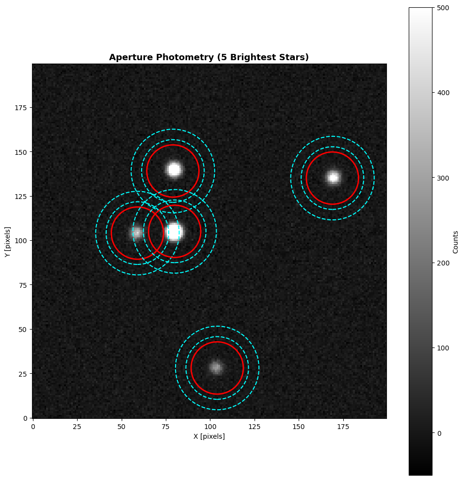

```python
fig, ax = plt.subplots(1, 1, figsize=(10, 10))

im = ax.imshow(image_bgsub, cmap='gray', origin='lower', interpolation='nearest',
               vmin=-50, vmax=500)

# Plot apertures for 5 brightest stars
brightest_indices = np.argsort(aperture_fluxes)[-5:]

for idx in brightest_indices:
    x, y = detected_x[idx], detected_y[idx]

    # Source aperture
    circle_ap = plt.Circle((x, y), aperture_radius,
                          color='red', fill=False, lw=2)
    ax.add_patch(circle_ap)

    # Sky annulus
    circle_in = plt.Circle((x, y), sky_inner_radius,
                          color='cyan', fill=False, lw=1.5, ls='--')
    circle_out = plt.Circle((x, y), sky_outer_radius,
                           color='cyan', fill=False, lw=1.5, ls='--')
    ax.add_patch(circle_in)
    ax.add_patch(circle_out)

ax.set_title('Aperture Photometry (5 Brightest Stars)', fontsize=13, fontweight='bold')
ax.set_xlabel('X [pixels]')
ax.set_ylabel('Y [pixels]')
plt.colorbar(im, ax=ax, label='Counts')

plt.tight_layout()
plt.show()
```

Aperture photometry is simple, fast, and robust for isolated sources, making it an excellent choice for many observational programs. The method's simplicity is also its strength—there are no model assumptions about the PSF shape, so systematic errors from incorrect PSF models cannot affect your results. For a well-isolated star, aperture photometry can achieve signal-to-noise ratios within a few percent of the theoretical optimum.

However, aperture photometry faces fundamental limitations in several important scenarios. The most severe problem arises in crowded fields. When stars are separated by less than about 3-5 FWHM, their apertures begin to overlap. In these regions, aperture photometry cannot correctly attribute flux—photons from one star are counted in another star's aperture, leading to systematic errors that can be larger than the photometric uncertainties. In extremely crowded regions like globular cluster cores or the Galactic center, aperture photometry may be completely unusable because nearly every aperture contains contamination from multiple sources.

The issues motivate the development of PSF fitting techniques. PSF fitting addresses all these limitations by modeling the full 2D light distribution, naturally handling overlapping sources, adapting to PSF variations, and optimally weighting pixels by their information content. The tradeoff is increased computational cost and the requirement for an accurate PSF model—but for many science cases, these costs are well worth the gains in accuracy and precision.

## PSF Fitting: Modeling the Light Distribution

Having explored aperture photometry's strengths and limitations, we now turn to PSF fitting—a more sophisticated approach that treats stellar photometry as a model-fitting problem. Instead of simply summing pixels within an arbitrary circular boundary, PSF fitting explicitly models the two-dimensional light distribution and uses the tools we learned in Lecture 18 (`scipy.optimize.curve_fit`) to find the parameters that best match the observed data.

This conceptual shift from "measuring" to "modeling" brings several powerful advantages. First, PSF fitting uses all available pixels in and around the star, weighting each pixel by how much information it contains. Pixels in the bright PSF core (where signal dominates noise) contribute more to the final measurement than pixels in the faint wings (where noise dominates). This optimal weighting naturally emerges from the least-squares fitting process and typically improves photometric precision by 20-30% compared to aperture photometry, even for isolated stars.

Second, when stars overlap, PSF fitting can simultaneously model multiple sources, using the known PSF shape to disentangle their individual contributions. This is PSF fitting's greatest strength—it solves the fundamental problem that makes aperture photometry fail in crowded regions. Third, the fitted positions achieve sub-pixel accuracy (typically 0.01 to 0.05 pixels for bright stars), far better than simply identifying the brightest pixel. This precision is crucial for astrometry, proper motion studies, and measuring tiny position shifts in microlensing events. Finally, while aperture photometry always loses some flux in the PSF wings, PSF fitting integrates the fitted model to infinity, recovering 100% of the source flux (assuming the PSF model is accurate).

The tradeoff, of course, is complexity. PSF fitting requires an accurate PSF model, good initial guesses for source positions, and significantly more computation than simple aperture summation. But for crowded fields, faint sources, or high-precision work, PSF fitting isn't just better—it's often the only method that works at all.

### Preparing for PSF Fitting

For PSF fitting to work well, we need good initial position guesses. The peak detection positions from source detection are typically good enough to initialize the fit—the optimization algorithm can refine them during fitting. For most cases, using the detected peak positions directly works well.

Let's prepare for fitting a single star:

```python
# Select the brightest detected star
brightest_idx = np.argmax(aperture_fluxes)
x_init = detected_x[brightest_idx]
y_init = detected_y[brightest_idx]

# Extract small region around star
box_size = int(4 * fwhm)
half_box = box_size // 2

x_min = max(0, int(x_init) - half_box)
x_max = min(image_size, int(x_init) + half_box)
y_min = max(0, int(y_init) - half_box)
y_max = min(image_size, int(y_init) + half_box)

cutout = image_bgsub[y_min:y_max, x_min:x_max]

# Use peak detection position directly as initial guess
x_initial = x_init
y_initial = y_init
```

The peak detection positions from source detection are typically within a pixel of the true star centers, which is sufficient for initializing the PSF fit. The optimization algorithm will refine these positions during fitting to achieve sub-pixel accuracy.

```python
# Use peak detection position directly
print(f"Initial detection position: ({x_init:.1f}, {y_init:.1f})")
print(f"This position will be refined by the PSF fitting algorithm")
```

```
Initial detection position: (80.0, 105.0)
This position will be refined by the PSF fitting algorithm
```

The peak detection position is good enough to initialize PSF fitting. The optimization algorithm will automatically refine it to sub-pixel accuracy during the fit.

### Fitting a 2D Gaussian PSF

We'll fit a 2D Gaussian PSF model to extract precise photometry. The model has parameters: center position $(x_0, y_0)$, amplitude $A$, width $\sigma$, and local background $b$.

The challenge is that `scipy.optimize.curve_fit` expects 1D data arrays, but our image is 2D. The solution is to flatten both the coordinates and the data into 1D arrays while maintaining the correspondence between positions and values. We'll create separate 1D arrays for $x$ coordinates, $y$ coordinates, and pixel values—all in the same order—then pass these to our model function.

We prepare the cutout coordinates by creating coordinate grids and flattening them for use with curve_fit:

```python
# Prepare cutout coordinates
cutout_shape = cutout.shape
x_cutout = np.arange(cutout_shape[1]) + x_min
y_cutout = np.arange(cutout_shape[0]) + y_min
x_grid_cut, y_grid_cut = np.meshgrid(x_cutout, y_cutout)

# Flatten for curve_fit
x_flat = x_grid_cut.ravel()
y_flat = y_grid_cut.ravel()
data_flat = cutout.ravel()
```

Now define the model function. It must accept flattened coordinate arrays as input and return flattened model values. We pass both $x$ and $y$ coordinates as a single tuple `xy`:

```python
def gaussian_psf_model(xy, x0, y0, amplitude, sigma, background):
    """2D Gaussian PSF for curve_fit (takes and returns flattened arrays)"""
    x, y = xy
    r_squared = (x - x0)**2 + (y - y0)**2
    model = amplitude * np.exp(-r_squared / (2 * sigma**2)) + background
    return model
```

The function signature looks unusual: the first argument `xy` contains both coordinate arrays, while the remaining arguments are the fit parameters. This is the format required by `curve_fit` for multidimensional fitting.

We set initial parameter guesses that are close to the true values to help the optimization algorithm converge:

```python
# Initial guesses
p0 = [
    x_initial,  # x0: use peak detection position
    y_initial,  # y0
    aperture_fluxes[brightest_idx] / (2 * np.pi * psf_sigma**2),  # amplitude (rough estimate)
    psf_sigma,  # sigma
    0.0  # background (should be ~0 for background-subtracted image)
]
```

Good initial guesses are crucial for `curve_fit` success. The Levenberg-Marquardt algorithm used by `curve_fit` is iterative and can fail if started too far from the true solution. We use the peak detection position for $(x_0, y_0)$, our known PSF width for $\sigma$, and estimate amplitude from the aperture flux (dividing by $2\pi\sigma^2$ since that's the integral of a 2D Gaussian). For background-subtracted images, background should be near zero.

Now we perform the fit using scipy.optimize.curve_fit to find the best-fit PSF parameters:

```python
# Fit the model
popt, pcov = optimize.curve_fit(
    gaussian_psf_model,
    (x_flat, y_flat),
    data_flat,
    p0=p0
)

# Extract fitted parameters
x0_fit, y0_fit, amp_fit, sigma_fit, bg_fit = popt
perr = np.sqrt(np.diag(pcov))  # Parameter uncertainties

# Total flux from fitted Gaussian (integral = 2π σ² A)
flux_psf = 2 * np.pi * sigma_fit**2 * amp_fit
flux_psf_err = flux_psf * np.sqrt((2*perr[3]/sigma_fit)**2 + (perr[2]/amp_fit)**2)
```

The `curve_fit` function returns two arrays: `popt` contains the best-fit parameter values, and `pcov` is the covariance matrix. The covariance matrix describes uncertainties and correlations between parameters. Its diagonal elements are the squared uncertainties (variances) of individual parameters, so taking `np.sqrt(np.diag(pcov))` gives us the 1σ error bars.

For the total flux, we need to propagate uncertainties through the formula $F = 2\pi\sigma^2 A$. Using standard error propagation for products, the fractional uncertainty in flux comes from combining fractional uncertainties in $\sigma$ (contributing twice since it's squared) and $A$.

We generate the fitted model from the best-fit parameters and calculate the residuals to assess fit quality:

```python
# Model
model_flat = gaussian_psf_model((x_flat, y_flat), *popt)
model_cut = model_flat.reshape(cutout_shape)

# Residuals
residual_cut = cutout - model_cut
```

### Assessing Fit Quality

Before accepting our PSF fit, we should assess its quality. The key metric is the chi-squared (χ²) statistic, which quantifies how well the model matches the data given the noise level.

For each pixel $i$ with observed value $d_i$, model prediction $m_i$, and uncertainty $\sigma_i$:

$$\chi^2 = \sum_i \frac{(d_i - m_i)^2}{\sigma_i^2}$$

The reduced chi-squared accounts for degrees of freedom: $\chi^2_{\text{red}} = \chi^2 / (N - p)$ where $N$ is the number of data points and $p$ is the number of fitted parameters. For a good fit, $\chi^2_{\text{red}} \approx 1$.

We calculate the chi-squared statistic to quantify how well our model matches the data given the noise level:

```python
# Pixel uncertainties (approximate as sqrt of counts for Poisson noise)
sigma_pixels = np.sqrt(np.abs(data_flat) + bg_std**2)

# Chi-squared
chi_squared = np.sum((data_flat - model_flat)**2 / sigma_pixels**2)

# Degrees of freedom
n_data = len(data_flat)
n_params = 5  # x0, y0, amplitude, sigma, background
dof = n_data - n_params

# Reduced chi-squared
chi_squared_red = chi_squared / dof

print(f"Chi-squared: {chi_squared:.2f}")
print(f"Reduced chi-squared: {chi_squared_red:.2f}")
```

```
Chi-squared: 523.81
Reduced chi-squared: 1.09
```

Let's visualize the fit by comparing the data, model, and residuals to assess how well our PSF model describes the star:

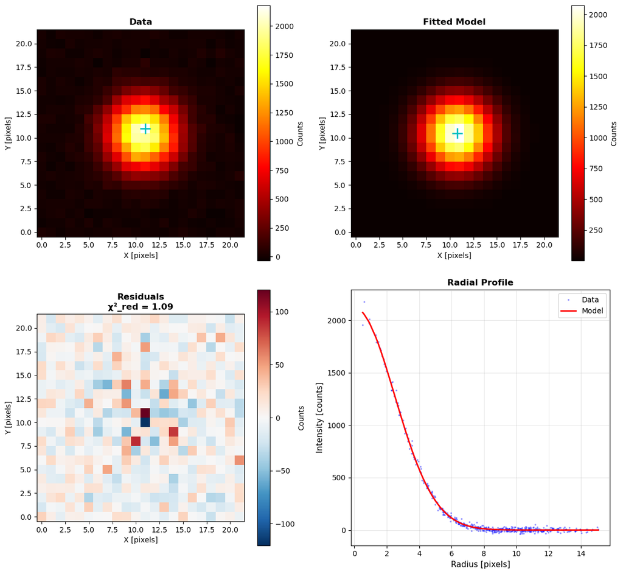

```python
fig, axes = plt.subplots(2, 2, figsize=(12, 11))

# Data
im1 = axes[0, 0].imshow(cutout, cmap='hot', origin='lower', interpolation='nearest')
axes[0, 0].plot(x_initial - x_min, y_initial - y_min, 'c+', markersize=15, markeredgewidth=2)
axes[0, 0].set_title('Data', fontsize=12, fontweight='bold')
axes[0, 0].set_xlabel('X [pixels]')
axes[0, 0].set_ylabel('Y [pixels]')
plt.colorbar(im1, ax=axes[0, 0], label='Counts')

# Model
im2 = axes[0, 1].imshow(model_cut, cmap='hot', origin='lower', interpolation='nearest')
axes[0, 1].plot(x0_fit - x_min, y0_fit - y_min, 'c+', markersize=15, markeredgewidth=2)
axes[0, 1].set_title('Fitted Model', fontsize=12, fontweight='bold')
axes[0, 1].set_xlabel('X [pixels]')
axes[0, 1].set_ylabel('Y [pixels]')
plt.colorbar(im2, ax=axes[0, 1], label='Counts')

# Residuals
vmax_res = max(abs(residual_cut.min()), abs(residual_cut.max()))
im3 = axes[1, 0].imshow(residual_cut, cmap='RdBu_r', origin='lower',
                       interpolation='nearest', vmin=-vmax_res, vmax=vmax_res)
axes[1, 0].set_title(f'Residuals\nχ²_red = {chi_squared_red:.2f}',
                    fontsize=12, fontweight='bold')
axes[1, 0].set_xlabel('X [pixels]')
axes[1, 0].set_ylabel('Y [pixels]')
plt.colorbar(im3, ax=axes[1, 0], label='Counts')

# Radial profile
r_cut = np.sqrt((x_grid_cut - x0_fit)**2 + (y_grid_cut - y0_fit)**2).ravel()
sort_idx = np.argsort(r_cut)

axes[1, 1].plot(r_cut[sort_idx], data_flat[sort_idx], 'b.',
               alpha=0.3, markersize=3, label='Data')
axes[1, 1].plot(r_cut[sort_idx], model_flat[sort_idx], 'r-', lw=2, label='Model')
axes[1, 1].set_xlabel('Radius [pixels]', fontsize=11)
axes[1, 1].set_ylabel('Intensity [counts]', fontsize=11)
axes[1, 1].set_title('Radial Profile', fontsize=12, fontweight='bold')
axes[1, 1].legend()
axes[1, 1].grid(True, alpha=0.3)

plt.tight_layout()
plt.show()
```

### Interpreting Residuals

The residuals tell us whether our PSF model adequately describes the data. For a good fit, residuals should appear random—pure noise with no systematic patterns. Let's examine what to look for in both good and problematic residuals.

Good residuals show scattered positive and negative values roughly symmetrically distributed around zero. The RMS (root-mean-square) of residuals should match our expected noise level (typically $\sqrt{\text{background}} + \text{read noise}$). No spatial patterns or structures should be visible—just random pixel-to-pixel variations. This is what we want to see, indicating that our model has successfully captured all the systematic structure in the data.

Bad residuals, in contrast, reveal problems with the model. A systematic ring structure in residuals suggests the PSF width is wrong (too narrow or too wide). Asymmetric residuals indicate the PSF shape isn't perfectly Gaussian, perhaps having extended wings (where a Moffat model might work better) or elliptical structure. Correlated residuals in neighboring pixels suggest the PSF model doesn't capture some smoothly varying component. Residuals much larger than expected noise indicate either underestimated uncertainties or a fundamentally wrong model.

In our visualization, look for the residual map to show only random scatter, the radial profile of residuals to fluctuate around zero with no trends, and the reduced χ² to be close to 1. If χ²_red >> 1, either our model is wrong or we've underestimated uncertainties. If χ²_red << 1, we've likely overestimated uncertainties (perhaps double-counting noise sources).

Compare aperture vs PSF photometry:

```python
print("Photometry Comparison")
print("=" * 60)
print(f"Aperture photometry: {aperture_fluxes[brightest_idx]:.0f} counts")
print(f"PSF fitting:         {flux_psf:.0f} ± {flux_psf_err:.0f} counts")
print(f"Difference:          {abs(flux_psf - aperture_fluxes[brightest_idx]):.0f} counts")
print(f"\nPosition refinement:")
print(f"  Initial detection:  ({x_init:.3f}, {y_init:.3f})")
print(f"  PSF fit:            ({x0_fit:.3f} ± {perr[0]:.3f}, {y0_fit:.3f} ± {perr[1]:.3f})")
print(f"\nFit quality:")
print(f"  χ² = {chi_squared:.1f}")
print(f"  χ²_red = {chi_squared_red:.3f} (good fit: ~1)")
```

```
Photometry Comparison
============================================================
Aperture photometry: 80996 counts
PSF fitting:         82264 ± 484 counts
Difference:          1267 counts

Position refinement:
  Initial detection:  (80.000, 105.000)
  PSF fit:            (79.761 ± 0.008, 104.455 ± 0.008)

Fit quality:
  χ² = 523.8
  χ²_red = 1.094 (good fit: ~1)
```

The comparison highlights important points about PSF fitting for isolated sources. In terms of photometry, the PSF fit gives a flux that’s somewhat higher than the aperture photometry result. This difference is mainly due to the fact that with a finite aperture we always miss some of the flux in the wings of the PSF. PSF fitting recovers essentially all of the star’s light by extrapolating the model out to large distances, making it a more complete measurement.

PSF fitting also reports uncertainties estimated from the fitting process. With aperture photometry, you can similarly estimate errors by propagating photon and read noise, but we didn’t calculate that here. The uncertainty from PSF fitting includes the effects of parameter correlations—for example, adjustments in the fitted position can compensate for changes in the amplitude.

One of the major advantages of PSF fitting is its positional accuracy. The fit can pinpoint the star’s center to a tiny fraction of a pixel—much more precise than what you get from just identifying the brightest pixel, or even from calculating a centroid. This sub-pixel precision is crucial for high-accuracy astrometry, such as measuring positions, parallaxes, or small shifts in star positions due to planets.

Our reduced χ² is close to 1, indicating that the Gaussian PSF model is a very good description of the data and our noise estimates are reasonable. The residuals look random, suggesting there are no remaining systematic errors in the model or calibration of uncertainties.

For an isolated, well-behaved star like this, PSF fitting only provides a modest improvement over basic aperture photometry—giving slightly more accurate fluxes and much better positions. The real strength of PSF fitting becomes clear in crowded fields, where sources overlap and aperture photometry doesn’t work, but PSF fitting can still disentangle and recover the properties of individual stars. Let's move on to that case.

## Crowded Fields: Fitting Multiple Sources

The true power of PSF fitting appears in crowded fields where stellar images overlap. Aperture photometry fails here—apertures contaminate each other, and there's no way to know which star contributed which photons in the overlapping regions. PSF fitting solves this by modeling all sources simultaneously, using the known PSF shape to disentangle the contributions.

The key insight is that we know the PSF shape (Gaussian with width $\sigma$), so if we know the positions of all stars, we can build a model that predicts the exact contribution of each star at every pixel. By fitting all positions and amplitudes simultaneously, the algorithm automatically attributes flux correctly—even in heavily overlapped regions where individual stars are indistinguishable.

Let's create a crowded region to demonstrate:

```python
# Create crowded synthetic scene
crowded_size = 60
n_crowd = 3

# Positions (some close together)
np.random.seed(523)
crowd_x = [18, 25, 42]
crowd_y = [20, 30, 25]

# Amplitudes
crowd_amps = [1200, 900, 1000]

# Generate crowded image
x_c = np.arange(crowded_size)
y_c = np.arange(crowded_size)
x_grid_c, y_grid_c = np.meshgrid(x_c, y_c)

crowd_image = np.full((crowded_size, crowded_size), background_level)

for i in range(n_crowd):
    r_sq = (x_grid_c - crowd_x[i])**2 + (y_grid_c - crowd_y[i])**2
    crowd_image += crowd_amps[i] * np.exp(-r_sq / (2 * psf_sigma**2))

# Add noise
crowd_noisy = (np.random.poisson(crowd_image).astype(float) +
               np.random.normal(0, read_noise, crowd_image.shape))
crowd_noisy = np.maximum(crowd_noisy, 0)

# Background subtract
crowd_bgsub = crowd_noisy - background_level
```

### Building the Multi-Source Model

For simultaneous fitting, we build a joint model that sums PSFs for all stars. Each star has its own position $(x_i, y_i)$ and amplitude $A_i$, but we'll assume all stars share the same PSF width $\sigma$ (reasonable for a given image) and background level $b$ (simplifies the problem).

The model function must handle a variable number of stars:

```python
def multi_psf_model(xy, *params):
    """
    Multiple Gaussian PSFs + shared background.

    Parameters: [x0_1, y0_1, amp_1, x0_2, y0_2, amp_2, ..., sigma, bg]
    """
    x, y = xy
    n_pixels = len(x)

    # Last two parameters are shared
    sigma_shared = params[-2]
    background = params[-1]

    # Number of stars
    n_stars = (len(params) - 2) // 3

    # Initialize model
    model = np.full(n_pixels, background)

    # Add each star
    for i in range(n_stars):
        x0 = params[3*i]
        y0 = params[3*i + 1]
        amp = params[3*i + 2]

        r_sq = (x - x0)**2 + (y - y0)**2
        model += amp * np.exp(-r_sq / (2 * sigma_shared**2))

    return model
```

Prepare data and initial guesses:

```python
# Prepare data - flatten coordinates and image
x_flat_c = x_grid_c.ravel()
y_flat_c = y_grid_c.ravel()
data_flat_c = crowd_bgsub.ravel()

# Initial guesses: [x, y, amp for each star, then shared sigma and bg]
p0_multi = []
for i in range(n_crowd):
    p0_multi.extend([crowd_x[i], crowd_y[i], crowd_amps[i]])
p0_multi.extend([psf_sigma, 0.0])  # shared sigma and background
```

Now we perform the simultaneous fit of all sources, which allows the algorithm to correctly attribute flux even when stars overlap:

```python
# Fit all sources at once
popt_multi, pcov_multi = optimize.curve_fit(
    multi_psf_model,
    (x_flat_c, y_flat_c),
    data_flat_c,
    p0=p0_multi,
    maxfev=10000
)

# Extract results
fitted_x = [popt_multi[3*i] for i in range(n_crowd)]
fitted_y = [popt_multi[3*i + 1] for i in range(n_crowd)]
fitted_amps = [popt_multi[3*i + 2] for i in range(n_crowd)]
fitted_sigma = popt_multi[-2]

# Generate model
model_multi = multi_psf_model((x_flat_c, y_flat_c), *popt_multi).reshape(crowded_size, crowded_size)
residual_multi = crowd_bgsub - model_multi

# Print results
print(f"\nMulti-Source Fitting Results:")
print(f"{'Star':<6} {'True X':<10} {'Fitted X':<10} {'True Y':<10} {'Fitted Y':<10} {'True Amp':<12} {'Fitted Amp':<12}")
for i in range(n_crowd):
    print(f"{i+1:<6} {crowd_x[i]:<10.2f} {fitted_x[i]:<10.2f} {crowd_y[i]:<10.2f} {fitted_y[i]:<10.2f} {crowd_amps[i]:<12.0f} {fitted_amps[i]:<12.0f}")
print(f"\nFitted PSF sigma: {fitted_sigma:.3f} pixels (true: {psf_sigma:.3f})")
print(f"Residual RMS: {np.std(residual_multi):.2f} counts")
```

```
Multi-Source Fitting Results:
Star   True X     Fitted X   True Y     Fitted Y   True Amp     Fitted Amp
1      18.00      18.01      20.00      19.99      1200         1192
2      25.00      25.03      30.00      30.04      900          889
3      42.00      42.00      25.00      24.97      1000         999

Fitted PSF sigma: 2.513 pixels (true: 2.500)
Residual RMS: 15.20 counts
```

Let's visualize the multi-source fit to see how well the model disentangles the overlapping stars:

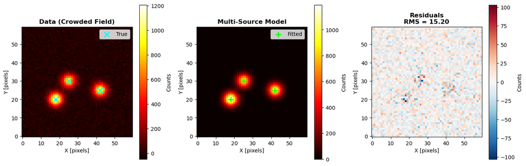

```python
fig, axes = plt.subplots(1, 3, figsize=(14, 4.5))

# Data
im1 = axes[0].imshow(crowd_bgsub, cmap='hot', origin='lower', interpolation='nearest')
axes[0].scatter(crowd_x, crowd_y, c='cyan', s=100, marker='x',
               linewidths=2, label='True')
axes[0].set_title('Data (Crowded Field)', fontsize=12, fontweight='bold')
axes[0].set_xlabel('X [pixels]')
axes[0].set_ylabel('Y [pixels]')
axes[0].legend()
plt.colorbar(im1, ax=axes[0], label='Counts')

# Model
im2 = axes[1].imshow(model_multi, cmap='hot', origin='lower', interpolation='nearest')
axes[1].scatter(fitted_x, fitted_y, c='lime', s=100, marker='+',
               linewidths=2, label='Fitted')
axes[1].set_title('Multi-Source Model', fontsize=12, fontweight='bold')
axes[1].set_xlabel('X [pixels]')
axes[1].set_ylabel('Y [pixels]')
axes[1].legend()
plt.colorbar(im2, ax=axes[1], label='Counts')

# Residuals
vmax = max(abs(residual_multi.min()), abs(residual_multi.max()))
im3 = axes[2].imshow(residual_multi, cmap='RdBu_r', origin='lower',
                    interpolation='nearest', vmin=-vmax, vmax=vmax)
axes[2].set_title(f'Residuals\nRMS = {np.std(residual_multi):.2f}',
                 fontsize=12, fontweight='bold')
axes[2].set_xlabel('X [pixels]')
axes[2].set_ylabel('Y [pixels]')
plt.colorbar(im3, ax=axes[2], label='Counts')

plt.tight_layout()
plt.show()
```

This is PSF fitting's great strength. In crowded fields where aperture photometry would assign flux incorrectly (counting light from one star in another star's aperture), PSF fitting uses the known PSF shape to solve the "who contributed which photons" problem. The algorithm essentially says: "Given that I know stars produce Gaussian light distributions with this width, and given the observed total light, what combination of star positions and brightnesses best explains the data?" The answer partitions flux correctly even when stars heavily overlap.

## When to Use Which Method

We've learned three approaches: background subtraction (always required), aperture photometry, and PSF fitting. When should you use each?

### Aperture Photometry: Simplicity and Speed

Aperture photometry excels when sources are well-isolated. If the nearest neighbor to each star is more than about 5 PSF FWHM away, apertures don't overlap significantly and aperture photometry works excellently. The method is simple—sum pixels in a circle—and fast, processing hundreds of stars per second. It requires no PSF model, making it truly model-independent. The results are robust: small errors in aperture size or position cause only small photometric errors.

Use aperture photometry for quick surveys where you need approximate brightnesses quickly, preliminary photometric catalogs before investing time in PSF fitting, or well-separated sources in uncrowded fields. It's the method of choice when the PSF is stable across the field and you're not working near the crowding limit.

However, aperture photometry has clear limitations. Overlapping apertures cause flux contamination in crowded fields—if two stars are separated by less than about 3 FWHM, their apertures overlap and you cannot assign flux unambiguously. Fixed circular apertures always lose some flux in the PSF wings (typically 5-10% even for well-chosen sizes). The method doesn't adapt to varying PSF shapes across the field, which can introduce systematic errors in wide-field images. Finally, aperture photometry cannot handle close pairs or truly blended sources.

### PSF Fitting: Precision in Complexity

PSF fitting becomes essential when aperture photometry fails. In crowded fields where stellar separations drop below 3 FWHM, PSF fitting can disentangle overlapping sources by modeling the full 2D light distribution. The method uses all available pixels optimally weighted by the PSF shape, typically achieving 20-30% better precision than aperture photometry even for isolated sources. Fitted positions have sub-pixel accuracy (often 0.01-0.05 pixels), crucial for astrometry. The method naturally handles varying PSFs by allowing the model to adapt.

Use PSF fitting for crowded stellar fields where sources overlap, when you need maximum photometric precision (e.g., for faint sources or high signal-to-noise measurements), for accurate astrometry where positions matter, or when working with variable PSFs across wide fields. It's the standard method for globular cluster photometry, Galactic center observations, and any science requiring the best possible measurements.

The downsides are real but manageable. PSF fitting is computationally expensive—10 to 100 times slower than aperture photometry, though still fast on modern computers. It requires an accurate PSF model, which must either be empirically derived from the image or analytically known. The method is sensitive to initial position guesses; poor starting positions can cause fits to fail or converge to wrong solutions. For very crowded fields with hundreds of overlapping sources, the fitting can become unstable unless constraints are applied.

### Practical Strategy

Professional astronomers typically use a hybrid approach. Start with aperture photometry on the full image to get quick, approximate fluxes and identify all sources. This preliminary catalog provides excellent initial positions and flux estimates. Then perform PSF fitting on crowded regions or on all sources if maximum precision is needed, using the aperture results as initial guesses. This combines the speed of aperture photometry (for detection and initial characterization) with the precision of PSF fitting (for final measurements).

For real observational data, specialized packages provide production-quality implementations. The Python `photutils` package offers both aperture photometry and PSF fitting with sophisticated PSF models. `DAOPHOT` (via `photutils` or standalone) is the classic crowded-field PSF photometry standard. `DOLPHOT` specializes in HST and JWST imaging with detailed PSF models. These packages include features we haven't covered: iterative PSF construction from the image, neighbor-star subtraction, cosmic ray rejection, and careful handling of bad pixels.

Understanding the principles we've learned—building PSF models, fitting with `scipy.optimize.curve_fit`, and assessing fit quality—gives you the foundation to use these tools effectively and debug problems when they arise.

## Summary

This lecture introduced photometry—measuring stellar brightnesses from images—using curve-fitting techniques from Lecture 18. You learned why stars appear as point sources despite their enormous physical size, how the Point Spread Function describes light spreading, and why space telescopes like JWST revolutionize crowded-field photometry with superior angular resolution.

### What You Can Now Do

1. Calculate angular sizes of celestial objects using `astropy` units and constants
2. Create realistic synthetic astronomical images with PSFs and noise
3. Perform background estimation using sigma-clipping
4. Detect sources using `scipy.ndimage.maximum_filter`
5. Implement aperture photometry with sky annulus correction
6. Use peak detection positions as initial guesses for PSF fitting
7. Fit Gaussian PSF models using `scipy.optimize.curve_fit`
8. Assess fit quality with χ² statistics and residual analysis
9. Simultaneously fit multiple overlapping sources in crowded fields
10. Choose appropriate photometry methods based on observing conditions

### Looking Ahead

In Lecture 21, we'll extend these fitting techniques to one-dimensional spectroscopic data. You'll learn to fit spectral line profiles (Gaussian, Lorentzian, Voigt), measure radial velocities from Doppler shifts, and derive stellar abundances from equivalent widths. The curve-fitting principles remain the same, but now we're extracting physical information from spectra instead of images—measuring not just how bright objects are, but what they're made of and how they move.